# How to fit and bootstrap hydraulics parameters

```r
library(hydrafit)
```

### Estimation of parameters

The aim of this vignette is to illustrate an example of estimating parameters and bootstrapping confidence intervals around the percent loss in hydraulic conductivity. The functions assume that the data is in organized by species, and includes at least leaf water potential value (often in MPa) and leaf hydraulic conductance or stomatal conductance measurements (often in mmol m<sup>-2</sup> s<sup>-1</sup>). The data can be log adjusted if you’d like and put in the same data set using `data.type` column. The default is to create the column and input 1 for all entries. Here, `data.type` is created and data.frames to store data from the model estimation are created (i.e., Linear, Exponential, Exponential2, Logistic, and Sigmoidal).

```r
# load data
if(require(dplyr)){
cebe <- hydrafit::cebe_efm %>%
  dplyr::mutate(data.type = rep(1, dim(cebe_efm)[1]), .before=psi) }
cebe$to_split <- paste(cebe$species, cebe$data.type)
# declare the data frame to store the results
modelfitting_results_linear <-
  data.frame(
    Species = as.character(),
    data.type = as.character(),
    A = numeric(),
    B = numeric(),
    C = numeric(),
    D = numeric(),
    loglikeli = numeric(),
    rsq = numeric(),
    slope = numeric(),
    AIC = numeric(),
    AICcorr = numeric(),
    sterror1 = numeric(),
    sterror2 = numeric(),
    sterror3 = numeric(),
    sterror4 = numeric(),
    N = numeric()
  )
modelfitting_results_logistic <-
  data.frame(
    Species = as.character(),
    data.type = as.character(),
    A = numeric(),
    B = numeric(),
    C = numeric(),
    D = numeric(),
    loglikeli = numeric(),
    rsq = numeric(),
    slope = numeric(),
    AIC = numeric(),
    AICcorr = numeric(),
    sterror1 = numeric(),
    sterror2 = numeric(),
    sterror3 = numeric(),
    sterror4 = numeric(),
    N = numeric()
  )
modelfitting_results_sigmoidal <-
  data.frame(
    Species = as.character(),
    data.type = as.character(),
    A = numeric(),
    B = numeric(),
    C = numeric(),
    D = numeric(),
    loglikeli = numeric(),
    rsq = numeric(),
    slope = numeric(),
    AIC = numeric(),
    AICcorr = numeric(),
    sterror1 = numeric(),
    sterror2 = numeric(),
    sterror3 = numeric(),
    sterror4 = numeric(),
    N = numeric()
  )
modelfitting_results_exp1 <-
  data.frame(
    Species = as.character(),
    data.type = as.character(),
    A = numeric(),
    B = numeric(),
    C = numeric(),
    D = numeric(),
    loglikeli = numeric(),
    rsq = numeric(),
    slope = numeric(),
    AIC = numeric(),
    AICcorr = numeric(),
    sterror1 = numeric(),
    sterror2 = numeric(),
    sterror3 = numeric(),
    sterror4 = numeric(),
    N = numeric()
  )
modelfitting_results_exp2 <-
  data.frame(
    Species = as.character(),
    data.type = as.character(),
    A = numeric(),
    B = numeric(),
    C = numeric(),
    D = numeric(),
    loglikeli = numeric(),
    rsq = numeric(),
    slope = numeric(),
    AIC = numeric(),
    AICcorr = numeric(),
    sterror1 = numeric(),
    sterror2 = numeric(),
    sterror3 = numeric(),
    sterror4 = numeric(),
    N = numeric()
  )

# specific list of species for for loops

species_list <- unique(cebe$to_split)
```

Now, we preform the fitting procedures using the `likelihood` function and fill in the data for each model type. **NOTE**: Make sure that you check for NAs in the final outputs. Also, a common error is about the best fitting model is not the potential best fit. Check with the `?anneal` function for more information.

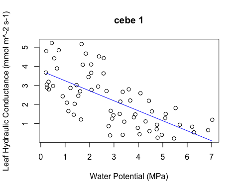

```r
#Linear
#pdf(file = here('outputs','Linear_fits.pdf'), width =8.5, height=5, onefile=T)

#Open a pdf file to save fitted curve plots in

#For every species, fit the curve and record the results
#cli::cli_progress_bar("Fitting curves (Linear)", total=length(species_list))
for (ii in 1:length(species_list)){
  (subset(cebe, cebe$to_split == species_list[ii], select =c(1:dim(cebe)[2])) -> data_by_sp)
  Linear_fits = fit_linear(data_by_sp, Linear, plot=T, xlab="Water Potential (MPa)", ylab="Leaf Hydraulic Conductance (mmol m^-2 s-1)")
  Linear_fits$D.NA<- NA # placeholder to keep all of the data frames the same size
  Linear_fits$sterror.NA <- NA
  rbind(modelfitting_results_linear, as.data.frame(Linear_fits))-> modelfitting_results_linear
  #cli::cli_progress_update()
}
```

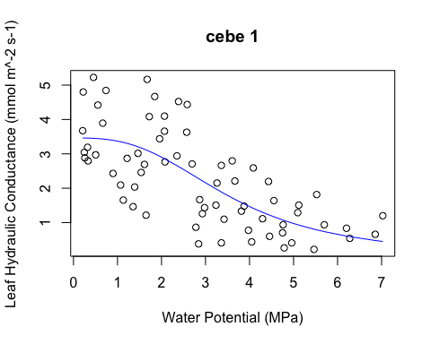

```r
#dev.off()

#estimate the pX values
modelfitting_results_linear$psi_k20<- (0.8-1)*(-modelfitting_results_linear$A.A)*-1/(modelfitting_results_linear$B.B)
modelfitting_results_linear$psi_k50<- (0.5-1)*(-modelfitting_results_linear$A.A)*-1/(modelfitting_results_linear$B.B)
modelfitting_results_linear$psi_k80<- (0.2-1)*(-modelfitting_results_linear$A.A)*-1/(modelfitting_results_linear$B.B)
modelfitting_results_linear$psi_k95<- (0.05-1)*(-modelfitting_results_linear$A.A)*-1/(modelfitting_results_linear$B.B)


# PX values with max at 0.1 MPa
modelfitting_results_linear$gmax_at0.1 <- (modelfitting_results_linear$B.B*0.1)+modelfitting_results_linear$A.A
modelfitting_results_linear$psi_k20_at0.1<- ((0.8*modelfitting_results_linear$gmax_at0.1)-modelfitting_results_linear$A.A)/(modelfitting_results_linear$B.B)
modelfitting_results_linear$psi_k50_at0.1<- ((0.5*modelfitting_results_linear$gmax_at0.1)-modelfitting_results_linear$A.A)/(modelfitting_results_linear$B.B)
modelfitting_results_linear$psi_k80_at0.1<- ((0.2*modelfitting_results_linear$gmax_at0.1)-modelfitting_results_linear$A.A)/(modelfitting_results_linear$B.B)
modelfitting_results_linear$psi_k95_at0.1<- ((0.05*modelfitting_results_linear$gmax_at0.1)-modelfitting_results_linear$A.A)/(modelfitting_results_linear$B.B)


#Logistic

#Declare the pdf file to hold the plots
#pdf(file = here('outputs','Logistic_fits.pdf'), width =8.5, height=5, onefile=T)

#cli::cli_progress_bar("Fitting curves (logistic)", total=length(species_list))
for (ii in 1:length(species_list)){
  subset(cebe, cebe$to_split == species_list[ii], select = c(1:dim(cebe)[2])) -> data_by_sp
  define_parsL(data_by_sp) -> par_estimates
  parsL=par_estimates[[1]]
  par_loL=par_estimates[[2]]
  par_highL=par_estimates[[3]]
  Logistic_fits = fit_nonlinear(data_by_sp, parsL, par_loL, par_highL, model_type = "log", plot=T,xlab="Water Potential (MPa)", ylab="Leaf Hydraulic Conductance (mmol m^-2 s-1)")
  rbind(modelfitting_results_logistic, as.data.frame(Logistic_fits))-> modelfitting_results_logistic
 # cli::cli_progress_update()
}
```

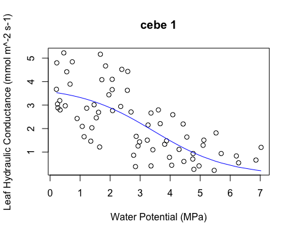

```r
#dev.off()

modelfitting_results_logistic$psi_k20<- modelfitting_results_logistic$C.Xo*(1/0.8-1)^(1/modelfitting_results_logistic$B.B)
modelfitting_results_logistic$psi_k50<- modelfitting_results_logistic$C.Xo*(1/0.5-1)^(1/modelfitting_results_logistic$B.B)
modelfitting_results_logistic$psi_k80<- modelfitting_results_logistic$C.Xo*(1/0.2-1)^(1/modelfitting_results_logistic$B.B)
modelfitting_results_logistic$psi_k95<- modelfitting_results_logistic$C.Xo*(1/0.05-1)^(1/modelfitting_results_logistic$B.B)

# PX values with max at 0.1 MPa
modelfitting_results_logistic$gmax_at0.1 <- (modelfitting_results_logistic$A.A)/(1+((0.1/modelfitting_results_logistic$C.Xo)^modelfitting_results_logistic$B.B))
modelfitting_results_logistic$psi_k20_at0.1<- (modelfitting_results_logistic$C.Xo)*(((modelfitting_results_logistic$A.A)/(0.8*modelfitting_results_logistic$gmax_at0.1)-1)^(1/modelfitting_results_logistic$B.B))
modelfitting_results_logistic$psi_k50_at0.1<- (modelfitting_results_logistic$C.Xo)*(((modelfitting_results_logistic$A.A)/(0.5*modelfitting_results_logistic$gmax_at0.1)-1)^(1/modelfitting_results_logistic$B.B))
modelfitting_results_logistic$psi_k80_at0.1<- (modelfitting_results_logistic$C.Xo)*(((modelfitting_results_logistic$A.A)/(0.2*modelfitting_results_logistic$gmax_at0.1)-1)^(1/modelfitting_results_logistic$B.B))
modelfitting_results_logistic$psi_k95_at0.1<- (modelfitting_results_logistic$C.Xo)*(((modelfitting_results_logistic$A.A)/(0.05*modelfitting_results_logistic$gmax_at0.1)-1)^(1/modelfitting_results_logistic$B.B))

#Sigmoidal

#Declare the pdf file to hold the plots
#pdf(file = here('outputs','Sigmoidal_fits.pdf'), width =8.5, height=5, onefile=T)

#cli::cli_progress_bar("Fitting curves (Sigmoidal)", total=length(species_list))
for (ii in 1:length(species_list)){
  subset(cebe, cebe$to_split == species_list[ii], select =c(1:dim(cebe)[2])) -> data_by_sp
  define_parsS(data_by_sp) -> par_estimates
  parsS=par_estimates[[1]]
  par_loS=par_estimates[[2]]
  par_highS=par_estimates[[3]]
  Sigmoidal_fits = fit_nonlinear(data_by_sp, parsS, par_loS, par_highS, model_type= "sig", plot=T,xlab="Water Potential (MPa)", ylab="Leaf Hydraulic Conductance (mmol m^-2 s-1)")
  rbind(modelfitting_results_sigmoidal, as.data.frame(Sigmoidal_fits))-> modelfitting_results_sigmoidal
  #cli::cli_progress_update()
}
```

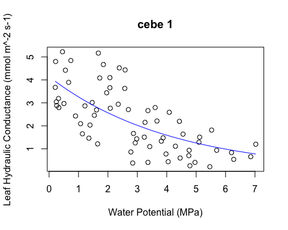

```r
#dev.off()

modelfitting_results_sigmoidal$psi_k20<- modelfitting_results_sigmoidal$C.Xo - modelfitting_results_sigmoidal$B.B*log(1/0.8 -1)
modelfitting_results_sigmoidal$psi_k50<- modelfitting_results_sigmoidal$C.Xo - modelfitting_results_sigmoidal$B.B*log(1/0.5 -1)
modelfitting_results_sigmoidal$psi_k80<- modelfitting_results_sigmoidal$C.Xo - modelfitting_results_sigmoidal$B.B*log(1/0.2 -1)
modelfitting_results_sigmoidal$psi_k95<- modelfitting_results_sigmoidal$C.Xo - modelfitting_results_sigmoidal$B.B*log(1/0.05 -1)

# PX values with max at 0.1 MPa
modelfitting_results_sigmoidal$gmax_at0.1 <- (modelfitting_results_sigmoidal$A.A)/(1+exp(-((0.1-modelfitting_results_sigmoidal$C.Xo)/modelfitting_results_sigmoidal$B.B)))
modelfitting_results_sigmoidal$psi_k20_at0.1<- -modelfitting_results_sigmoidal$B.B*(modelfitting_results_sigmoidal$A.A-(0.8*modelfitting_results_sigmoidal$gmax_at0.1)-log(0.8*modelfitting_results_sigmoidal$gmax_at0.1)) + modelfitting_results_sigmoidal$C.Xo
modelfitting_results_sigmoidal$psi_k50_at0.1<- -modelfitting_results_sigmoidal$B.B*(modelfitting_results_sigmoidal$A.A-(0.5*modelfitting_results_sigmoidal$gmax_at0.1)-log(0.5*modelfitting_results_sigmoidal$gmax_at0.1)) + modelfitting_results_sigmoidal$C.Xo
modelfitting_results_sigmoidal$psi_k80_at0.1<- -modelfitting_results_sigmoidal$B.B*(modelfitting_results_sigmoidal$A.A-(0.2*modelfitting_results_sigmoidal$gmax_at0.1)-log(0.2*modelfitting_results_sigmoidal$gmax_at0.1)) + modelfitting_results_sigmoidal$C.Xo
modelfitting_results_sigmoidal$psi_k95_at0.1<- -modelfitting_results_sigmoidal$B.B*(modelfitting_results_sigmoidal$A.A-(0.05*modelfitting_results_sigmoidal$gmax_at0.1)-log(0.05*modelfitting_results_sigmoidal$gmax_at0.1)) + modelfitting_results_sigmoidal$C.Xo


#Exponential


#pdf(file = here('outputs','Exponential_fits.pdf'), width =8.5, height=5, onefile=T)
#cli::cli_progress_bar("Fitting curves (Exponential)", total=length(species_list))
for (ii in 1:length(species_list)){
  subset(cebe, cebe$to_split == species_list[ii], select =c(1:dim(cebe)[2])) -> data_by_sp
  define_parsE(data_by_sp) -> par_estimates
  parsE=par_estimates[[1]]
  par_loE=par_estimates[[2]]
  par_highE=par_estimates[[3]]
  Exponential_fits = fit_nonlinear(data_by_sp, parsE, par_loE, par_highE, model_type = "exp", plot=T, xlab="Water Potential (MPa)", ylab="Leaf Hydraulic Conductance (mmol m^-2 s-1)")
  Exponential_fits$D.NA<- NA
  Exponential_fits$sterror.NA <- NA
  rbind(modelfitting_results_exp1, as.data.frame(Exponential_fits))-> modelfitting_results_exp1
  #cli::cli_progress_update()
}
```

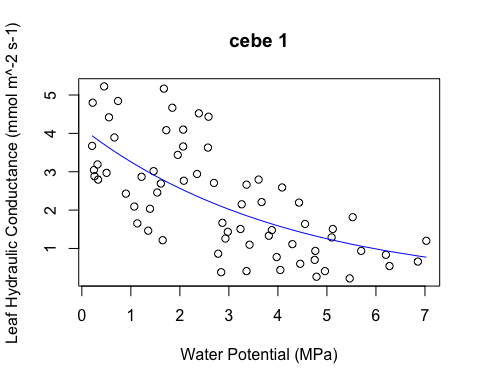

```r
#dev.off()

modelfitting_results_exp1$psi_k20<- log(0.8)/(-modelfitting_results_exp1$B.B)
modelfitting_results_exp1$psi_k50<- log(0.5)/(-modelfitting_results_exp1$B.B)
modelfitting_results_exp1$psi_k80<- log(0.2)/(-modelfitting_results_exp1$B.B)
modelfitting_results_exp1$psi_k95<- log(0.05)/(-modelfitting_results_exp1$B.B)

# PX values with max at 0.1 MPa
modelfitting_results_exp1$gmax_at0.1 <- modelfitting_results_exp1$A.A * exp(-modelfitting_results_exp1$B.B*0.1)
modelfitting_results_exp1$psi_k20_at0.1<- (log((0.8*modelfitting_results_exp1$gmax_at0.1)/modelfitting_results_exp1$A.A))/(-modelfitting_results_exp1$B.B)
modelfitting_results_exp1$psi_k50_at0.1<- (log((0.5*modelfitting_results_exp1$gmax_at0.1)/modelfitting_results_exp1$A.A))/(-modelfitting_results_exp1$B.B)
modelfitting_results_exp1$psi_k80_at0.1<- (log((0.2*modelfitting_results_exp1$gmax_at0.1)/modelfitting_results_exp1$A.A))/(-modelfitting_results_exp1$B.B)
modelfitting_results_exp1$psi_k95_at0.1<- (log((0.05*modelfitting_results_exp1$gmax_at0.1)/modelfitting_results_exp1$A.A))/(-modelfitting_results_exp1$B.B)


#Exponential2

#pdf(file = here('outputs','Exponential2_fits.pdf'), width =8.5, height=5, onefile=T)

#cli::cli_progress_bar("Fitting curves (Exponential 2)", total=length(species_list))
for (ii in 1:length(species_list)){
  subset(cebe, cebe$to_split == species_list[ii], select =c(1:dim(cebe)[2])) -> data_by_sp
  define_parsE2(data_by_sp) -> par_estimates
  parsE2=par_estimates[[1]]
  par_loE2=par_estimates[[2]]
  par_highE2=par_estimates[[3]]
  Exponential2_fits = fit_nonlinear(data_by_sp,  parsE2, par_loE2, par_highE2, model_type= "exp2", plot=T, xlab="Water Potential (MPa)", ylab="Leaf Hydraulic Conductance (mmol m^-2 s-1)")
  #########Update from Megan: this fit returns NaN (not a number) or "N/A" instead of NA at times (probably when C is very small),
  ####and this converts everything else in the modelfitting_results columns to NA-
  ###this replaces the NaNs with -999, so they'll be easy to find
  Exponential2_fits[which(is.na(Exponential2_fits)== TRUE)] = -999
  Exponential2_fits[which(Exponential2_fits== "N/A")] = -999

  rbind(modelfitting_results_exp2, as.data.frame(Exponential2_fits))-> modelfitting_results_exp2
 # cli::cli_progress_update()
}
```

```r
#dev.off()

modelfitting_results_exp2$psi_k20<- log(0.8- modelfitting_results_exp2$C.C/modelfitting_results_exp2$A.A)/(-modelfitting_results_exp2$B.B)
modelfitting_results_exp2$psi_k50<- log(0.5- modelfitting_results_exp2$C.C/modelfitting_results_exp2$A.A)/(-modelfitting_results_exp2$B.B)
modelfitting_results_exp2$psi_k80<- log(0.2- modelfitting_results_exp2$C.C/modelfitting_results_exp2$A.A)/(-modelfitting_results_exp2$B.B)
modelfitting_results_exp2$psi_k95<- log(0.05- modelfitting_results_exp2$C.C/modelfitting_results_exp2$A.A)/(-modelfitting_results_exp2$B.B)

# PX values with max at 0.1 MPa
modelfitting_results_exp2$gmax_at0.1 <- modelfitting_results_exp2$C.C+(modelfitting_results_exp2$A.A * exp(-modelfitting_results_exp2$B.B*0.1))
modelfitting_results_exp2$psi_k20_at0.1<- -((log(((0.8*modelfitting_results_exp2$gmax_at0.1)-modelfitting_results_exp2$C.C)/modelfitting_results_exp2$A.A))/(modelfitting_results_exp2$B.B))
modelfitting_results_exp2$psi_k50_at0.1<- -((log(((0.5*modelfitting_results_exp2$gmax_at0.1)-modelfitting_results_exp2$C.C)/modelfitting_results_exp2$A.A))/(modelfitting_results_exp2$B.B))
modelfitting_results_exp2$psi_k80_at0.1<- -((log(((0.2*modelfitting_results_exp2$gmax_at0.1)-modelfitting_results_exp2$C.C)/modelfitting_results_exp2$A.A))/(modelfitting_results_exp2$B.B))
modelfitting_results_exp2$psi_k95_at0.1<- -((log(((0.05*modelfitting_results_exp2$gmax_at0.1)-modelfitting_results_exp2$C.C)/modelfitting_results_exp2$A.A))/(modelfitting_results_exp2$B.B))
```

### Model selection with `fx_select()`

Once parameters for each model type are created for each species, we select the best fitting model by lowest corrected AIC (AICc). Sometimes the fits do not match the data well or in ways that are questionable physiologically (i.e., the line drawn is below the points and skirt extreme low conductance values before $\Psi_{leaf}$ = -1 MPa. This is a key reason to **plot** the data in the preceding steps. One justification for substituting another model type for the lower AICc model is if the replacement is within 2 AICc units. Before bootstrapping confidence intervals one may remove the observations from the `mod_bestfit` object created below. and replace them with the equivalent rows in the appropriate model data.frame.

```r
#rename files for concision and legibility
df_lin<-modelfitting_results_linear
df_sig<-modelfitting_results_sigmoidal
df_log<-modelfitting_results_logistic
df_exp1<-modelfitting_results_exp1
df_exp2<-modelfitting_results_exp2

mod_bestfit_temp<-fx_select(df_lin, df_log, df_sig, df_exp1, df_exp2)#produce df with the best model fit for each species

if(require("dplyr")){
mod_bestfit<-mod_bestfit_temp%>%
  dplyr::mutate_at(3:26, as.numeric)
}
```

### Bootstrapping PX

To bootstrap confidence intervals, we use the `bootPX()` function. This function takes the best fitting model chosen by the lowest AICc values across the 5 model types. The function takes each parameter estimate for each species and its error value and samples from the normal distribution constructed from the estimate and its metric of dispersion. The function used in the model fitting, `anneal()` creates “standard errors” from the square root of the hessian matrices for each modelled function parameter. The square root of hessian matrices is the standard deviation of the estimate. Therefore, it is used as such when constructing the distribution for resampling. Future renditions of this may utilize the native function bootstrapping function in R.

#### For more information:

See here for more information about the annealing function and how it works: [https://www.rdocumentation.org/packages/likelihood/versions/1.7/topics/Simulated%20Annealing%20Algorithm](https://www.rdocumentation.org/packages/likelihood/versions/1.7/topics/Simulated%20Annealing%20Algorithm%60)

The hessian matrix information from within the function itself is here: https://github.com/cran/likelihood/blob/master/R/anneal.R. See lines 742-797 specifically within the code for where it is calculated.

```r
# Bootstrapping Psi_KXX ---------------------------------------------------

#standard error function
se<-function(x){
  sd(x, na.rm = T)/sqrt(length(x))# specifying na.rm=T because sometimes the predicted parameters estimate negative values and log(negative #)=NA
}

output_boot <-
  data.frame(
    species = character(),
    pred_mean = numeric(),
    pred_median = numeric(),
    pred_se = numeric(),
    conf_low = numeric(),
    conf_high = numeric()
  )

alpha=0.05

set.seed(1994) #  For reproducibility

for( i in 1:dim(mod_bestfit)[1]){

  suppressWarnings(boot_vals<-bootPX(mod_bestfit,
                    fx_type=mod_bestfit[i,"data.type"],
                    px=0.5)%>%unlist())# suppressing warnings for the NAs that are produced

  boot_mean<-mean(boot_vals, na.rm=T)# specifying na.rm=T because sometimes the predicted parameters estimate negative values and log(negative #)=NA

  boot_se<-se(boot_vals)

  boot_median<-median(boot_vals,na.rm = T)# specifying na.rm=T because sometimes the predicted parameters estimate negative values and log(negative #)=NA
  #determine confidence intervals
  deg_of_freedom= length(boot_vals)
  t_score=qt(p=alpha/2, df=deg_of_freedom, lower.tail = F)

  margin_error<-t_score*boot_se

  conf.low<-mod_bestfit[i,"psi_k50"]-margin_error # using the predicted pX value to make the error make sense
  conf.high<-mod_bestfit[i,"psi_k50"]+margin_error

  output_boot[i,1]<-mod_bestfit[i,"species"]
  output_boot[i,2]<-boot_mean
  output_boot[i,3]<-boot_median
  output_boot[i,4]<-boot_se
  output_boot[i,5]<-conf.low
  output_boot[i,6]<-conf.high
}

output_boot
```

```
#>   species pred_mean pred_median    pred_se conf_low conf_high
#> 1    cebe    3.5765    3.581281 0.01047286 3.566599  3.607701
```